# Project Report: Contains important outcomes as relevant to tasks expected in the project

## This does not complete the complete code. Code is uploaded in source code section.

```python
from IPython.display import Image
```

## Project 1 - ECommerce

### Description

#### Problem Statement:

Amazon is an online shopping website that now caters to millions of people everywhere. Over 34,000 consumer reviews for Amazon brand products like Kindle, Fire TV Stick and more are provided. The dataset has attributes like brand, categories, primary categories, reviews.title, reviews.text, and the sentiment. Sentiment is a categorical variable with three levels "Positive", "Negative“, and "Neutral". For a given unseen data, the sentiment needs to be predicted. You are required to predict Sentiment or Satisfaction of a purchase based on multiple features and review text.

#### Dataset Snapshot:

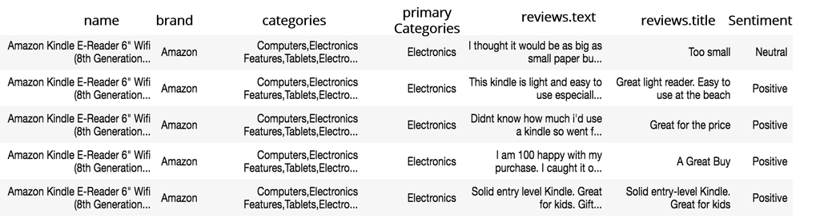

```python
Image('1566552102_Picture1.png')
```

#### Project Task: Week 1

Class Imbalance Problem:

1. Perform an EDA on the dataset.

   ```
   a)  See what a positive, negative, and neutral review looks like

   b)  Check the class count for each class. It’s a class imbalance problem.
   ```

2. Convert the reviews in Tf-Idf score.
3. Run multinomial Naive Bayes classifier. Everything will be classified as positive because of the class imbalance.

```python
#Performing EDA
pandas_profiling.ProfileReport(df)
```

[interactive chart not shown]

Observation from profiling report: 3749 Positive comments, 158 Neutral comments and 93 Negative comments. This is an imbalanced dataset

```python
df.sentiment.value_counts()
```

```
Positive    3749
Neutral      158
Negative      93
Name: sentiment, dtype: int64
```

###### 'reviews.text' converted to tf-idf vectors

```python
X_features.head()
```

|  | 0 | 1 | 2 | 3 | 4 | 5 | 6 | 7 | 8 | 9 | ... | 3912 | 3913 | 3914 | 3915 | 3916 | 3917 | 3918 | 3919 | 3920 | 3921 |
| --- | --- | --- | --- | --- | --- | --- | --- | --- | --- | --- | --- | --- | --- | --- | --- | --- | --- | --- | --- | --- | --- |
| 0 | 0.0 | 0.0 | 0.0 | 0.0 | 0.0 | 0.0 | 0.0 | 0.0 | 0.0 | 0.0 | ... | 0.0 | 0.0 | 0.0 | 0.0 | 0.0 | 0.0 | 0.0 | 0.0 | 0.0 | 0.0 |
| 1 | 0.0 | 0.0 | 0.0 | 0.0 | 0.0 | 0.0 | 0.0 | 0.0 | 0.0 | 0.0 | ... | 0.0 | 0.0 | 0.0 | 0.0 | 0.0 | 0.0 | 0.0 | 0.0 | 0.0 | 0.0 |
| 2 | 0.0 | 0.0 | 0.0 | 0.0 | 0.0 | 0.0 | 0.0 | 0.0 | 0.0 | 0.0 | ... | 0.0 | 0.0 | 0.0 | 0.0 | 0.0 | 0.0 | 0.0 | 0.0 | 0.0 | 0.0 |
| 3 | 0.0 | 0.0 | 0.0 | 0.0 | 0.0 | 0.0 | 0.0 | 0.0 | 0.0 | 0.0 | ... | 0.0 | 0.0 | 0.0 | 0.0 | 0.0 | 0.0 | 0.0 | 0.0 | 0.0 | 0.0 |
| 4 | 0.0 | 0.0 | 0.0 | 0.0 | 0.0 | 0.0 | 0.0 | 0.0 | 0.0 | 0.0 | ... | 0.0 | 0.0 | 0.0 | 0.0 | 0.0 | 0.0 | 0.0 | 0.0 | 0.0 | 0.0 |

5 rows × 3922 columns

##### Multinomial Naive Bayes

###### Observation: Output after running multinomial NB. All reviews are predicted to be positive

```python
print(confusion_matrix(y_test, y_pred))
print(classification_report(y_test, y_pred))
```

```
[[  0   0  16]
 [  0   0  41]
 [  0   0 743]]
              precision    recall  f1-score   support

    Negative       0.00      0.00      0.00        16
     Neutral       0.00      0.00      0.00        41
    Positive       0.93      1.00      0.96       743

    accuracy                           0.93       800
   macro avg       0.31      0.33      0.32       800
weighted avg       0.86      0.93      0.89       800
```

###### Observation: All reviews are predicted to be positive

```python
y_pred
```

[output not shown]

[output cut: 106 more lines]

[output not shown]

##### Project Task: Week 2

##### Tackling Class Imbalance Problem:

- Oversampling or undersampling can be used to tackle the class imbalance problem.
- In case of class imbalance criteria, use the following metrices for evaluating model performance: precision, recall, F1-score, AUC-ROC curve. Use F1-Score as the evaluation criteria for this project.
- Use Tree-based classifiers like Random Forest and XGBoost.

Note: Tree-based classifiers work on two ideologies namely, Bagging or Boosting and have fine-tuning parameter which takes care of the imbalanced class.

###### Trying oversampling:

###### Output of multinomial NB with oversampled data

```python
print(confusion_matrix(y_test, y_pred_over))
print(classification_report(y_test, y_pred_over))
```

```
[[  7   0   9]
 [  1   6  34]
 [  9   3 731]]
              precision    recall  f1-score   support

    Negative       0.41      0.44      0.42        16
     Neutral       0.67      0.15      0.24        41
    Positive       0.94      0.98      0.96       743

    accuracy                           0.93       800
   macro avg       0.67      0.52      0.54       800
weighted avg       0.92      0.93      0.92       800
```

###### Best output of multinomial NB with varying over sampling strategies:

[[ 7 0 9]

[ 1 7 33]

[ 6 2 735]]

```
          precision    recall  f1-score   support

Negative       0.50      0.44      0.47        16
 Neutral       0.78      0.17      0.28        41
Positive       0.95      0.99      0.97       743

accuracy                           0.94       800
```

###### Using tree based classifier - Random forest classifier:

###### Output of using RF classifier

```python
print(confusion_matrix(y_test, y_pred_over_rf))
print(classification_report(y_test, y_pred_over_rf))
```

```
[[  0   0  16]
 [  0   0  41]
 [  0   0 743]]
              precision    recall  f1-score   support

    Negative       0.00      0.00      0.00        16
     Neutral       0.00      0.00      0.00        41
    Positive       0.93      1.00      0.96       743

    accuracy                           0.93       800
   macro avg       0.31      0.33      0.32       800
weighted avg       0.86      0.93      0.89       800
```

###### Using tree based classifier XGBoost Classifier:

###### Output of XGBoost Classifier:

```python
print(confusion_matrix(y_test, y_pred_over_xgb))
print(classification_report(y_test, y_pred_over_xgb))
```

```
[[  7   0   9]
 [  0  12  29]
 [  2   5 736]]
              precision    recall  f1-score   support

    Negative       0.78      0.44      0.56        16
     Neutral       0.71      0.29      0.41        41
    Positive       0.95      0.99      0.97       743

    accuracy                           0.94       800
   macro avg       0.81      0.57      0.65       800
weighted avg       0.93      0.94      0.93       800
```

###### Observation: XGBoost gave a better result than NB / RandomForest

###### Project Task: Week 3

###### Model Selection:

- Apply multi-class SVM’s and neural nets.
- Use possible ensemble techniques like: XGboost + oversampled_multinomial_NB.
- Assign a score to the sentence sentiment (engineer a feature called sentiment score). Use this engineered feature in the model and check for improvements. Draw insights on the same.

###### Applying multi-class SVMs

###### Output of multiclass SVM:

```python
poly_accuracy = accuracy_score(y_test, poly_pred)
poly_f1 = f1_score(y_test, poly_pred, average='weighted')
print('Accuracy (Polynomial Kernel): ', "%.2f" % (poly_accuracy*100))
print('F1 (Polynomial Kernel): ', "%.2f" % (poly_f1*100))
```

```
Accuracy (Polynomial Kernel):  94.38
F1 (Polynomial Kernel):  92.59
```

###### Applying neural nets

```python
#Create optimizer with non-default learning rate
sgd_optimizer = tf.keras.optimizers.SGD(lr=0.01)

#Compile the model

model.compile(optimizer=sgd_optimizer, loss='binary_crossentropy', \
              metrics=[tf.keras.metrics.Precision(), \
                       tf.keras.metrics.Recall(), \
                       tf.keras.metrics.SpecificityAtSensitivity(0.5), \
                       tf.keras.metrics.AUC(), 'accuracy'])
```

###### Output of neural network:

```python
from sklearn.metrics import confusion_matrix
from sklearn.metrics import f1_score
matrix = confusion_matrix(y_test, pred_y_test)
print(matrix)
#f1 = f1_score(y_test, pred_y_test)
#print('F1 score: %f' % f1)
```

```
[[732  11   0]
 [ 37   4   0]
 [  9   7   0]]
```

```python
Accuracy for neutral: 4/41, negative: 0/16
```

###### Output of neural network with oversampled data:

```python
matrix = confusion_matrix(y_test, pred_y_test_over)
print(matrix)
```

```
[[406 337   0]
 [ 11  30   0]
 [  2  14   0]]
```

###### Observation: Accuracy for neutral: 30/41, negative: 0/16; Oversampling improved accuracy of neutral not negative comments

###### Use possible ensemble techniques like: XGboost + oversampled_multinomial_NB.

###### Ensemble with MNB and oversampled XGBoost

```python
print(confusion_matrix(y_test, y_pred_nb))
print(classification_report(y_test, y_pred_nb))
```

```
[[  0   0  16]
 [  0   0  41]
 [  0   0 743]]
              precision    recall  f1-score   support

    Negative       0.00      0.00      0.00        16
     Neutral       0.00      0.00      0.00        41
    Positive       0.93      1.00      0.96       743

    accuracy                           0.93       800
   macro avg       0.31      0.33      0.32       800
weighted avg       0.86      0.93      0.89       800
```

###### Ouput of oversampled XGB:

```python
print(confusion_matrix(y_test, y_pred_over_xgb))
print(classification_report(y_test, y_pred_over_xgb))
```

```
[[  7   0   9]
 [  0  12  29]
 [  1   2 740]]
              precision    recall  f1-score   support

    Negative       0.88      0.44      0.58        16
     Neutral       0.86      0.29      0.44        41
    Positive       0.95      1.00      0.97       743

    accuracy                           0.95       800
   macro avg       0.89      0.58      0.66       800
weighted avg       0.94      0.95      0.94       800
```

###### Ensemble output with 20% weightage for MNB and 80% weightage for XGBoost:

```python
# Creating ensemble with Multinomial NB and oversampled XGBoost using weighted average.
# Giving more weightage to XGB due to better results

y_pred_ensemble=(y_pred_nb*0.2+y_pred_over_xgb*0.8)
```

```python
y_pred_ensemble
```

[output not shown]

[output cut: 22 more lines]

###### Assigning custom feature for Sentiment score:

```python
# Assign a score to the sentence sentiment (engineer a feature called sentiment score).
# Use this engineered feature in the model and check for improvements. Draw insights on
# the same.
```

```python
#logic behind sentiment score: if positive, score=5, if neutral, score=3, if negative, score=1

df = pd.read_csv('train_data.csv')
def assign_score (row):
   if row['sentiment'] == 'Positive' :
      return 5
   if row['sentiment'] == 'Neutral' :
      return 3
   if row['sentiment'] == 'Negative' :
      return 1
   return 0
```

###### Output with engineered sentiment score using XGB:

```python
print(confusion_matrix(y_test, y_pred_over_xgb))
print(classification_report(y_test, y_pred_over_xgb))
```

```
[[ 16   0   0]
 [  0  41   0]
 [  0   0 743]]
              precision    recall  f1-score   support

    Negative       1.00      1.00      1.00        16
     Neutral       1.00      1.00      1.00        41
    Positive       1.00      1.00      1.00       743

    accuracy                           1.00       800
   macro avg       1.00      1.00      1.00       800
weighted avg       1.00      1.00      1.00       800
```

###### Observeration: the above gives 100% accuracy since the score is a direct indication of the sentiments

##### Project Task: Week 4

###### Applying LSTM:

```
  1. Use LSTM for the previous problem (use parameters of LSTM like top-word, embedding-length, Dropout, epochs, number of layers, etc.)
   Hint: Another variation of LSTM, GRU (Gated Recurrent Units) can be tried as well.

  2. Compare the accuracy of neural nets with traditional ML based algorithms.

  3. Find the best setting of LSTM (Neural Net) and GRU that can best classify the reviews as positive, negative, and neutral.

   Hint: Use techniques like Grid Search, Cross-Validation and Random Search
```

###### Applying LSTM

```python
print('Test set\n  Loss: {:0.3f}\n  Recall: {:0.3f}'.format(accr[0],accr[1]))
```

```
Test set
  Loss: 0.229
  Recall: 0.923
```

###### Output of LSTM neural network:

```python
from sklearn.metrics import confusion_matrix, classification_report
from sklearn.metrics import f1_score
print(confusion_matrix(y_test, y_pred))
print(classification_report(y_test, y_pred))
```

```
[[  1   1   2]
 [  0   3  12]
 [  2   8 371]]
              precision    recall  f1-score   support

           0       0.33      0.25      0.29         4
           1       0.25      0.20      0.22        15
           2       0.96      0.97      0.97       381

    accuracy                           0.94       400
   macro avg       0.52      0.47      0.49       400
weighted avg       0.93      0.94      0.93       400
```

###### Observation: F1 scores for negative and neutral are 0.29 and 0.22

###### Find best parameters for maximum recall

```python
# Function to create model, required for KerasClassifier

def create_my_model(activation='relu'):
    #Initialize Sequential model
    model = Sequential()
    model.add(Embedding(MAX_NB_WORDS, EMBEDDING_DIM, input_length=X.shape[1]))
    model.add(SpatialDropout1D(0.2))
    model.add(LSTM(100, dropout=0.2, recurrent_dropout=0.2))
    model.add(Dense(3, activation='softmax'))
    model.compile(loss='categorical_crossentropy', optimizer='adam', metrics=['accuracy'])
    callbacks = [tf.keras.callbacks.EarlyStopping(monitor='val_loss', patience=2)]
    return model

# fix random seed for reproducibility
seed = 7
numpy.random.seed(seed)

# create model
model = KerasClassifier(build_fn=create_my_model, epochs=5, batch_size=32, verbose=0)
# define the grid search parameters
activation = ['softmax', 'softplus']
epochs=[5,10,15]
batch_size=[30,40,50]
#learn_rate = [0.001, 0.005, 0.01, 0.1]
param_grid = dict(activation=activation, epochs=epochs, batch_size=batch_size)#, learn_rate=learn_rate

grid = GridSearchCV(estimator=model, param_grid=param_grid, n_jobs=-1, cv=2)
grid_result = grid.fit(X_train[0:200,:], Y_train[0:200,:])
# summarize results
print("Best: %f using %s" % (grid_result.best_score_, grid_result.best_params_))
means = grid_result.cv_results_['mean_test_score']
stds = grid_result.cv_results_['std_test_score']
params = grid_result.cv_results_['params']
for mean, stdev, param in zip(means, stds, params):
    print("%f (%f) with: %r" % (mean, stdev, param))
```

```
Best: 0.925000 using {'activation': 'softmax', 'batch_size': 30, 'epochs': 5}
0.925000 (0.005000) with: {'activation': 'softmax', 'batch_size': 30, 'epochs': 5}
0.925000 (0.005000) with: {'activation': 'softmax', 'batch_size': 30, 'epochs': 10}
0.925000 (0.005000) with: {'activation': 'softmax', 'batch_size': 30, 'epochs': 15}
0.925000 (0.005000) with: {'activation': 'softmax', 'batch_size': 40, 'epochs': 5}
0.925000 (0.005000) with: {'activation': 'softmax', 'batch_size': 40, 'epochs': 10}
0.925000 (0.005000) with: {'activation': 'softmax', 'batch_size': 40, 'epochs': 15}
0.925000 (0.005000) with: {'activation': 'softmax', 'batch_size': 50, 'epochs': 5}
0.925000 (0.005000) with: {'activation': 'softmax', 'batch_size': 50, 'epochs': 10}
0.925000 (0.005000) with: {'activation': 'softmax', 'batch_size': 50, 'epochs': 15}
0.925000 (0.005000) with: {'activation': 'softplus', 'batch_size': 30, 'epochs': 5}
0.925000 (0.005000) with: {'activation': 'softplus', 'batch_size': 30, 'epochs': 10}
0.925000 (0.005000) with: {'activation': 'softplus', 'batch_size': 30, 'epochs': 15}
0.925000 (0.005000) with: {'activation': 'softplus', 'batch_size': 40, 'epochs': 5}
0.925000 (0.005000) with: {'activation': 'softplus', 'batch_size': 40, 'epochs': 10}
0.925000 (0.005000) with: {'activation': 'softplus', 'batch_size': 40, 'epochs': 15}
0.925000 (0.005000) with: {'activation': 'softplus', 'batch_size': 50, 'epochs': 5}
0.925000 (0.005000) with: {'activation': 'softplus', 'batch_size': 50, 'epochs': 10}
0.925000 (0.005000) with: {'activation': 'softplus', 'batch_size': 50, 'epochs': 15}
```

```python
#Running the model again with best parameters:
Best: 0.925000 using {'activation': 'softmax', 'batch_size': 30, 'epochs': 5}
```